# 项目成果：泰坦尼克号生存预测

### 关键词

数据分析流程，经典分析方法，模型性能测评

### 项目背景

通过多角度分析确定特征变量，使用sklearn机器学习包，调用用经典模型，对幸存率进行预测，最终给出模型解释。

### 获得技能

一般特征分析方法，调用经典模型，性能评价，通过决策树解释模型。

# 一、提出问题

1. 哪些单一特征群体的幸存率较大？
2. 怎样的复合特征群体的幸存率较大？
3. 最终选择的特征间如果存在较大相关性，是否会降低预测准确率？

# 二、数据加工

## 导入库

```python
# 添加会用到的库
import numpy as np
import pandas as pd
import os
import random as rnd
print(os.listdir('C:/Users/spark/Desktop/ML101/project-titanic/raw_data'))

# 可视化
import seaborn as sns
import matplotlib.pyplot as plt
# magic命令，确保作图在当前页面显示，但同行代码不能有中文
%matplotlib inline

# 机器学习
from sklearn.linear_model import LogisticRegression # 分类：逻辑回归
from sklearn.linear_model import SGDClassifier # 分类：梯度下降
from sklearn.svm import LinearSVC # 分类：支持向量机
from sklearn.tree import DecisionTreeClassifier # 分类：决策树
from sklearn.ensemble import RandomForestClassifier # 分类：随机森林
from sklearn.ensemble import GradientBoostingClassifier # 分类：梯度提升决策树
from sklearn.neighbors import KNeighborsClassifier # 分类：k邻近
from sklearn.naive_bayes import GaussianNB
from sklearn.linear_model import Perceptron
```

```
['test.csv', 'train.csv']
```

## 查看字段

```python
# 获取数据文件
train_df = pd.read_csv('C:/Users/spark/Desktop/ML101/project-titanic/raw_data/train.csv')
predict_df = pd.read_csv('C:/Users/spark/Desktop/ML101/project-titanic/raw_data/test.csv')
combined = [train_df, predict_df]
full_df = train_df.append(predict_df, ignore_index=True)
print(train_df.columns.values)
```

```
['PassengerId' 'Survived' 'Pclass' 'Name' 'Sex' 'Age' 'SibSp' 'Parch'
 'Ticket' 'Fare' 'Cabin' 'Embarked']
```

有一些二分类数据：survived，sex，embarked

还有一些数值型数据，可以分为离散的、连续的、时间序列的

- 离散的：sibsp(sibling/spouse)，parch（parents/children）
- 连续的：age，fare

```python
train_df.head()
```

|  | PassengerId | Survived | Pclass | Name | Sex | Age | SibSp | Parch | Ticket | Fare | Cabin | Embarked |
| --- | --- | --- | --- | --- | --- | --- | --- | --- | --- | --- | --- | --- |
| 0 | 1 | 0 | 3 | Braund, Mr. Owen Harris | male | 22.0 | 1 | 0 | A/5 21171 | 7.2500 | NaN | S |
| 1 | 2 | 1 | 1 | Cumings, Mrs. John Bradley (Florence Briggs Th... | female | 38.0 | 1 | 0 | PC 17599 | 71.2833 | C85 | C |
| 2 | 3 | 1 | 3 | Heikkinen, Miss. Laina | female | 26.0 | 0 | 0 | STON/O2. 3101282 | 7.9250 | NaN | S |
| 3 | 4 | 1 | 1 | Futrelle, Mrs. Jacques Heath (Lily May Peel) | female | 35.0 | 1 | 0 | 113803 | 53.1000 | C123 | S |
| 4 | 5 | 0 | 3 | Allen, Mr. William Henry | male | 35.0 | 0 | 0 | 373450 | 8.0500 | NaN | S |

survival:生存状态

pclass:船舱等级

embarked：登船地点

## 查看数据统计信息

```python
full_df.info()
```

```
<class 'pandas.core.frame.DataFrame'>
RangeIndex: 1309 entries, 0 to 1308
Data columns (total 12 columns):
Age            1046 non-null float64
Cabin          295 non-null object
Embarked       1307 non-null object
Fare           1308 non-null float64
Name           1309 non-null object
Parch          1309 non-null int64
PassengerId    1309 non-null int64
Pclass         1309 non-null int64
Sex            1309 non-null object
SibSp          1309 non-null int64
Survived       891 non-null float64
Ticket         1309 non-null object
dtypes: float64(3), int64(4), object(5)
memory usage: 122.8+ KB
```

```python
train_df.describe()
```

|  | PassengerId | Survived | Pclass | Age | SibSp | Parch | Fare |
| --- | --- | --- | --- | --- | --- | --- | --- |
| count | 891.000000 | 891.000000 | 891.000000 | 714.000000 | 891.000000 | 891.000000 | 891.000000 |
| mean | 446.000000 | 0.383838 | 2.308642 | 29.699118 | 0.523008 | 0.381594 | 32.204208 |
| std | 257.353842 | 0.486592 | 0.836071 | 14.526497 | 1.102743 | 0.806057 | 49.693429 |
| min | 1.000000 | 0.000000 | 1.000000 | 0.420000 | 0.000000 | 0.000000 | 0.000000 |
| 25% | 223.500000 | 0.000000 | 2.000000 | 20.125000 | 0.000000 | 0.000000 | 7.910400 |
| 50% | 446.000000 | 0.000000 | 3.000000 | 28.000000 | 0.000000 | 0.000000 | 14.454200 |
| 75% | 668.500000 | 1.000000 | 3.000000 | 38.000000 | 1.000000 | 0.000000 | 31.000000 |
| max | 891.000000 | 1.000000 | 3.000000 | 80.000000 | 8.000000 | 6.000000 | 512.329200 |

### 完整性

应fillna的字段：age，cabin（较多），embarked，fare

### 有效性

应drop的字段：passengerid，name，ticket，cabin缺乏有效信息

### 合并、分解特征

- sibsp+parch-->family
- name-->title
- age-->age_bands
- fare-->fare_ranges

### 经验假设

女性、孩子、高等舱的幸存率更高

# 三、数据探索

```python
# 验证假设
# Sex
train_df[['Sex', 'Survived']].groupby(['Sex'], as_index=False)\
.mean().sort_values(by='Survived', ascending=False)
```

|  | Sex | Survived |
| --- | --- | --- |
| 0 | female | 0.742038 |
| 1 | male | 0.188908 |

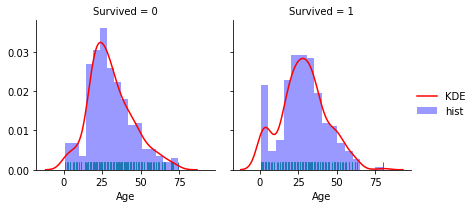

```python
# Age
g = sns.FacetGrid(train_df, col='Survived')
#g.map(plt.hist, 'Age', bins=20)
g.map(sns.distplot, 'Age',rug=True,
hist_kws={'color':'blue','label':'hist'},
kde_kws={'color':'red','label':'KDE'},)
g.add_legend()
```

### Observations

- 人数最多：15-35岁
- 幸存率高：婴儿（0-4岁），老年人（80岁）
- 幸存率低：15-25岁

```python
# Pclass
train_df[['Pclass', 'Survived']].groupby(['Pclass'], as_index=False)\
.mean().sort_values(by='Survived', ascending=False)
```

|  | Pclass | Survived |
| --- | --- | --- |
| 0 | 1 | 0.629630 |
| 1 | 2 | 0.472826 |
| 2 | 3 | 0.242363 |

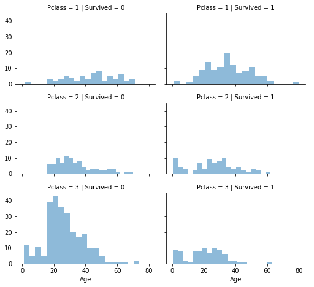

```python
# Pclass&Age
g = sns.FacetGrid(train_df, col='Survived', row='Pclass', height=2.2, aspect=1.6)
g.map(plt.hist, 'Age', alpha=0.5, bins=20)
g.add_legend()
```

### Observations

- 人数最多：pclass=3
- 幸存率高：pclass=1，婴儿（pclass=1，2）
- 幸存率低：pclass=3

### Decisions

特征选择：pclass=3的幸存率区分度大

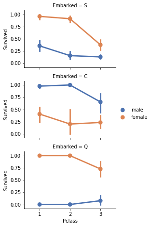

```python
# Embarked
g = sns.FacetGrid(train_df, row='Embarked', height=2.2, aspect=1.6)
g.map(sns.pointplot, 'Pclass', 'Survived', 'Sex', palette='deep')
g.add_legend()
```

### Observations

- 幸存率高：女性，男性（embarked=C）

### Decisions

特征选择：sex、embarked=C的幸存率区分度大

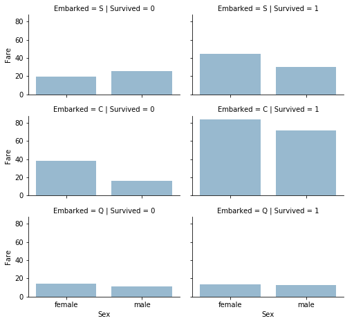

```python
# Fare
g = sns.FacetGrid(train_df, row='Embarked', col='Survived', height=2.2, aspect=1.6)
g.map(sns.barplot, 'Sex', 'Fare', alpha=.5, ci=None)
g.add_legend()
```

### Observations

- 幸存率高
  - 女性：S、C，且（平均）票价高
  - 男性：C，且（平均）票价高

### Decisions

特征选择：划分票价区间

# 四、数据再加工

### 修复完整性和无效性

```python
# 修复完整性和无效性
full_df['Age'].fillna(full_df['Age'].mean(), inplace=True)
full_df['Embarked'].fillna(full_df['Embarked'].dropna().mode()[0], inplace=True)
full_df['Fare'].fillna(full_df['Fare'].dropna().median(), inplace=True)
full_df.drop(['Cabin', 'Ticket'], axis=1, inplace=True)
full_df.info()
```

```
<class 'pandas.core.frame.DataFrame'>
RangeIndex: 1309 entries, 0 to 1308
Data columns (total 10 columns):
Age            1309 non-null float64
Embarked       1309 non-null object
Fare           1309 non-null float64
Name           1309 non-null object
Parch          1309 non-null int64
PassengerId    1309 non-null int64
Pclass         1309 non-null int64
Sex            1309 non-null object
SibSp          1309 non-null int64
Survived       891 non-null float64
dtypes: float64(3), int64(4), object(3)
memory usage: 102.3+ KB
```

### 特征转换：将类别转换为数字

```python
# 特征转换：将类别转换为数字
full_df['Sex'] = full_df['Sex'].map({'female':1, 'male':0}).astype(int)
full_df['Embarked'] = full_df['Embarked'].map({'S':0,'Q':1,'C':2}).astype(int)
```

```python
full_df.head()
```

|  | Age | Embarked | Fare | Name | Parch | PassengerId | Pclass | Sex | SibSp | Survived |
| --- | --- | --- | --- | --- | --- | --- | --- | --- | --- | --- |
| 0 | 22.0 | 0 | 7.2500 | Braund, Mr. Owen Harris | 0 | 1 | 3 | 0 | 1 | 0.0 |
| 1 | 38.0 | 2 | 71.2833 | Cumings, Mrs. John Bradley (Florence Briggs Th... | 0 | 2 | 1 | 1 | 1 | 1.0 |
| 2 | 26.0 | 0 | 7.9250 | Heikkinen, Miss. Laina | 0 | 3 | 3 | 1 | 0 | 1.0 |
| 3 | 35.0 | 0 | 53.1000 | Futrelle, Mrs. Jacques Heath (Lily May Peel) | 0 | 4 | 1 | 1 | 1 | 1.0 |
| 4 | 35.0 | 0 | 8.0500 | Allen, Mr. William Henry | 0 | 5 | 3 | 0 | 0 | 0.0 |

## 相关系数矩阵

```python
# 相关系数矩阵
r_df = full_df.corr()
r_df
```

|  | Age | Embarked | Fare | Parch | PassengerId | Pclass | Sex | SibSp | Survived |
| --- | --- | --- | --- | --- | --- | --- | --- | --- | --- |
| Age | 1.000000 | 0.071181 | 0.170851 | -0.130872 | 0.025731 | -0.366371 | -0.057397 | -0.190747 | -0.070323 |
| Embarked | 0.071181 | 1.000000 | 0.238131 | -0.044772 | 0.051977 | -0.185479 | 0.097960 | -0.065567 | 0.167675 |
| Fare | 0.170851 | 0.238131 | 1.000000 | 0.221635 | 0.031128 | -0.558683 | 0.185681 | 0.160349 | 0.257307 |
| Parch | -0.130872 | -0.044772 | 0.221635 | 1.000000 | 0.008942 | 0.018322 | 0.213125 | 0.373587 | 0.081629 |
| PassengerId | 0.025731 | 0.051977 | 0.031128 | 0.008942 | 1.000000 | -0.038354 | -0.013406 | -0.055224 | -0.005007 |
| Pclass | -0.366371 | -0.185479 | -0.558683 | 0.018322 | -0.038354 | 1.000000 | -0.124617 | 0.060832 | -0.338481 |
| Sex | -0.057397 | 0.097960 | 0.185681 | 0.213125 | -0.013406 | -0.124617 | 1.000000 | 0.109609 | 0.543351 |
| SibSp | -0.190747 | -0.065567 | 0.160349 | 0.373587 | -0.055224 | 0.060832 | 0.109609 | 1.000000 | -0.035322 |
| Survived | -0.070323 | 0.167675 | 0.257307 | 0.081629 | -0.005007 | -0.338481 | 0.543351 | -0.035322 | 1.000000 |

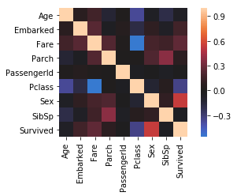

```python
# 热力图
#import matplotlib.pyplot as plt
#import seaborn as sns
f,ax = plt.subplots(figsize=(6,3)) # 设定画幅
sns.heatmap(r_df, vmax =1, square=True, center=0) # 生成热力图
# 调整坐标标签方向
#label_x = ax.get_xticklabels()
#plt.setp(label_x , rotation = 90)
plt.show()
```

### 特征转换：划分数值区间（分箱）

```python
# 划分数值区间
# Age
# 调试区间：查看年龄区间的幸存率
train_df['AgeBand'] = pd.cut(train_df['Age'], 4)
train_df[['AgeBand', 'Survived']].groupby(['AgeBand'], as_index=False)\
.mean().sort_values(by='AgeBand', ascending=True)
```

|  | AgeBand | Survived |
| --- | --- | --- |
| 0 | (0.34, 20.315] | 0.458101 |
| 1 | (20.315, 40.21] | 0.397403 |
| 2 | (40.21, 60.105] | 0.390625 |
| 3 | (60.105, 80.0] | 0.227273 |

```python
# 按照上方区间，修改Age为分组编号
full_df['Age'] = full_df['Age'].map(lambda x:0 if x<=20 else x)
full_df['Age'] = full_df['Age'].map(lambda x:1 if 20<x<=40 else x)
full_df['Age'] = full_df['Age'].map(lambda x:2 if 40<x<=60 else x)
full_df['Age'] = full_df['Age'].map(lambda x:3 if 60<x else x)
full_df['Age'] = full_df['Age'].map(lambda x:int(x))
```

```python
# Fare
# 调试区间：查看年龄区间的幸存率
train_df['FareBand'] = pd.qcut(train_df['Fare'], 4)
train_df[['FareBand', 'Survived']].groupby(['FareBand'], as_index=False)\
.mean().sort_values(by='FareBand', ascending=True)
```

|  | FareBand | Survived |
| --- | --- | --- |
| 0 | (-0.001, 7.91] | 0.197309 |
| 1 | (7.91, 14.454] | 0.303571 |
| 2 | (14.454, 31.0] | 0.454955 |
| 3 | (31.0, 512.329] | 0.581081 |

```python
full_df['Fare'] = full_df['Fare'].map(lambda x:0 if x<=7.91 else x)
full_df['Fare'] = full_df['Fare'].map(lambda x:1 if 7.91<x<=14.454 else x)
full_df['Fare'] = full_df['Fare'].map(lambda x:2 if 14.454<x<=31.0 else x)
full_df['Fare'] = full_df['Fare'].map(lambda x:3 if 31.0<x else x)
full_df['Fare'] = full_df['Fare'].map(lambda x:int(x))
full_df.head()
```

|  | Age | Embarked | Fare | Name | Parch | PassengerId | Pclass | Sex | SibSp | Survived |
| --- | --- | --- | --- | --- | --- | --- | --- | --- | --- | --- |
| 0 | 1 | 0 | 0 | Braund, Mr. Owen Harris | 0 | 1 | 3 | 0 | 1 | 0.0 |
| 1 | 1 | 2 | 3 | Cumings, Mrs. John Bradley (Florence Briggs Th... | 0 | 2 | 1 | 1 | 1 | 1.0 |
| 2 | 1 | 0 | 1 | Heikkinen, Miss. Laina | 0 | 3 | 3 | 1 | 0 | 1.0 |
| 3 | 1 | 0 | 3 | Futrelle, Mrs. Jacques Heath (Lily May Peel) | 0 | 4 | 1 | 1 | 1 | 1.0 |
| 4 | 1 | 0 | 1 | Allen, Mr. William Henry | 0 | 5 | 3 | 0 | 0 | 0.0 |

### 特征转换：从文本中截取关键字

```python
# Name
# 从name中提取title
def title_split(name):
    start = name.find(',') + 1
    end = name.find('.')
    return name[start:end].strip()

train_df['Title'] = train_df['Name'].map(title_split)
train_df['Title'].value_counts()
```

```
Mr              517
Miss            182
Mrs             125
Master           40
Dr                7
Rev               6
Mlle              2
Col               2
Major             2
Capt              1
Mme               1
the Countess      1
Jonkheer          1
Don               1
Lady              1
Ms                1
Sir               1
Name: Title, dtype: int64
```

```python
train_df['Title'] = train_df['Title'].map(lambda x:1 if x in ['Miss', 'Mrs'] else 0)
train_df[['Title', 'Survived']].groupby(['Title'], as_index=False)\
.mean().sort_values(by='Survived', ascending=True)
```

|  | Title | Survived |
| --- | --- | --- |
| 0 | 0 | 0.198630 |
| 1 | 1 | 0.736156 |

### Decisions

将Miss、Mrs分为一组，其它分为另一组。

```python
full_df['Title'] = full_df['Name'].map(title_split)
full_df['Title'] = full_df['Title'].map(lambda x:1 if x in ['Miss', 'Mrs'] else 0)
full_df.drop('Name', axis=1, inplace=True)
full_df.head()
```

|  | Age | Embarked | Fare | Parch | PassengerId | Pclass | Sex | SibSp | Survived | Title |
| --- | --- | --- | --- | --- | --- | --- | --- | --- | --- | --- |
| 0 | 1 | 0 | 0 | 0 | 1 | 3 | 0 | 1 | 0.0 | 0 |
| 1 | 1 | 2 | 3 | 0 | 2 | 1 | 1 | 1 | 1.0 | 1 |
| 2 | 1 | 0 | 1 | 0 | 3 | 3 | 1 | 0 | 1.0 | 1 |
| 3 | 1 | 0 | 3 | 0 | 4 | 1 | 1 | 1 | 1.0 | 1 |
| 4 | 1 | 0 | 1 | 0 | 5 | 3 | 0 | 0 | 0.0 | 0 |

```python
# sibsp+parch-->family
train_df['Family'] = train_df['Parch'] + train_df['SibSp'] + 1
train_df[['Family', 'Survived']].groupby(['Family'], as_index=False)\
.mean().sort_values(by='Family', ascending=True)
```

|  | Family | Survived |
| --- | --- | --- |
| 0 | 1 | 0.303538 |
| 1 | 2 | 0.552795 |
| 2 | 3 | 0.578431 |
| 3 | 4 | 0.724138 |
| 4 | 5 | 0.200000 |
| 5 | 6 | 0.136364 |
| 6 | 7 | 0.333333 |
| 7 | 8 | 0.000000 |
| 8 | 11 | 0.000000 |

```python
# family-SibSp
train_df[['SibSp', 'Survived']].groupby(['SibSp'], as_index=False)\
.mean().sort_values(by='SibSp', ascending=True)
```

|  | SibSp | Survived |
| --- | --- | --- |
| 0 | 0 | 0.345395 |
| 1 | 1 | 0.535885 |
| 2 | 2 | 0.464286 |
| 3 | 3 | 0.250000 |
| 4 | 4 | 0.166667 |
| 5 | 5 | 0.000000 |
| 6 | 8 | 0.000000 |

```python
# family-Parch
train_df[['Parch', 'Survived']].groupby(['Parch'], as_index=False)\
.mean().sort_values(by='Parch', ascending=True)
```

|  | Parch | Survived |
| --- | --- | --- |
| 0 | 0 | 0.343658 |
| 1 | 1 | 0.550847 |
| 2 | 2 | 0.500000 |
| 3 | 3 | 0.600000 |
| 4 | 4 | 0.000000 |
| 5 | 5 | 0.200000 |
| 6 | 6 | 0.000000 |

### Observations

- family、sibsp、parch的集中趋势是相似的，family对区分度没有更多帮助

### Decisions

不对sibsp、parch进行合并

```python
# 备选方法：特征转换：使用特征转换器
#from sklearn.feature_extraction import DictVectorizer
#vec = DictVectorizer(sparse=False)
#full_df = vec.fit_transform(full_df.to_dict(orient='record'))
#print vec.feature_names_
```

# 五、调用机器学习模型

```python
# 切分为原始训练集、预测集
len_train = len(train_df)
train_df = full_df.loc[:len_train-1, :]
predict_df = full_df.loc[len_train:, :]
print(train_df.shape, predict_df.shape)
```

```
(891, 10) (418, 10)
```

```python
# 将Survived值转换为int
train_df['Survived'] = train_df['Survived'].map(lambda x:int(x)).copy()
train_df.head()
```

|  | Age | Embarked | Fare | Parch | PassengerId | Pclass | Sex | SibSp | Survived | Title |
| --- | --- | --- | --- | --- | --- | --- | --- | --- | --- | --- |
| 0 | 1 | 0 | 0 | 0 | 1 | 3 | 0 | 1 | 0 | 0 |
| 1 | 1 | 2 | 3 | 0 | 2 | 1 | 1 | 1 | 1 | 1 |
| 2 | 1 | 0 | 1 | 0 | 3 | 3 | 1 | 0 | 1 | 1 |
| 3 | 1 | 0 | 3 | 0 | 4 | 1 | 1 | 1 | 1 | 1 |
| 4 | 1 | 0 | 1 | 0 | 5 | 3 | 0 | 0 | 0 | 0 |

```python
train_df['Sex'].value_counts()
```

```
0    577
1    314
Name: Sex, dtype: int64
```

```python
x = train_df.drop(['PassengerId', 'Survived'], axis=1)
y = train_df['Survived']
x_predict = predict_df.drop('Survived', axis=1)
x.shape, y.shape, x_predict.shape
```

```
((891, 8), (891,), (418, 9))
```

```python
x.head()
```

|  | Age | Embarked | Fare | Parch | Pclass | Sex | SibSp | Title |
| --- | --- | --- | --- | --- | --- | --- | --- | --- |
| 0 | 1 | 0 | 0 | 0 | 3 | 0 | 1 | 0 |
| 1 | 1 | 2 | 3 | 0 | 1 | 1 | 1 | 1 |
| 2 | 1 | 0 | 1 | 0 | 3 | 1 | 0 | 1 |
| 3 | 1 | 0 | 3 | 0 | 1 | 1 | 1 | 1 |
| 4 | 1 | 0 | 1 | 0 | 3 | 0 | 0 | 0 |

```python
# 将原始训练集切分为训练集和测试集
from sklearn.model_selection import train_test_split
x_train, x_test, y_train, y_test = train_test_split(x,y,random_state=33,test_size=0.25)
```

```python
# 调用模型，测评性能
# Logistics Regression、SGD、SVC均为参数模型，且需要标准化。
# 数据加工阶段，已使无需再标准化。

# 标准化方法
#from sklearn.preprocessing import StandardScaler
#ss = StandardScaler()
#x_train = ss.fit_transform(x_train)
#x_test = ss.transform(x_test)

# Logistics Regression
lr = LogisticRegression()
lr.fit(x_train, y_train)
acc_lr = lr.score(x_test, y_test)

# SGD
sgdc = SGDClassifier()
sgdc.fit(x_train, y_train)
acc_sgdc = sgdc.score(x_test, y_test)

# SVC
lsvc = LinearSVC()
lsvc.fit(x_train, y_train)
acc_lsvc = lsvc.score(x_test, y_test)
```

```python
# 决策树、集合模型均为参数模型，但不需要标准化，但需要将类别特征向量化
# 数据加工阶段，已处理类别特征

# 特征向量化方法
#from sklearn.feature_extraction import DictVectorizer
#vec = DictVectorizer()
#x_train = vec.fit_transform(x_train.to_dict(orient='record'))
#x_test = vec.transform(x_test.to_dict(orient='record'))

# Tree
dtc = DecisionTreeClassifier()
dtc.fit(x_train, y_train)
acc_dtc = dtc.score(x_test, y_test)

# Ensemble-RandomForestClassifier
rfc = RandomForestClassifier()
rfc.fit(x_train, y_train)
acc_rfc = rfc.score(x_test, y_test)

# Ensemble-GradientBoostingClassifier
gbc = GradientBoostingClassifier()
gbc.fit(x_train, y_train)
acc_gbc = gbc.score(x_test, y_test)
```

```python
# K-Neighbors：非参数模型，且需要标准化
knc = KNeighborsClassifier(n_neighbors=11)
knc.fit(x_train, y_train)
acc_knc = knc.score(x_test, y_test)
```

```python
# rank of score
models = pd.DataFrame({'Model':['Logistics Regression',
                                'SGD',
                                'SVC',
                                'Tree',
                                'Ensemble-RandomForestClassifier',
                                'Ensemble-GradientBoostingClassifier',
                                'K-Neighbors'],
                       'Score':[acc_lr,
                                acc_sgdc,
                                acc_lsvc,
                                acc_dtc,
                                acc_rfc,
                                acc_gbc,
                                acc_knc]})
models.sort_values(by='Score', ascending=False)
```

|  | Model | Score |
| --- | --- | --- |
| 5 | Ensemble-GradientBoostingClassifier | 0.843049 |
| 6 | K-Neighbors | 0.843049 |
| 2 | SVC | 0.825112 |
| 4 | Ensemble-RandomForestClassifier | 0.825112 |
| 0 | Logistics Regression | 0.820628 |
| 1 | SGD | 0.811659 |
| 3 | Tree | 0.811659 |

```python
# 性能测评方法
# 混淆矩阵：精确度、召回率、二者的调和平均数
#from sklearn.metrics import classification_report
```

### 模型可视化：以决策树为例

```python
# 小图
# from sklearn import tree
# tree.plot_tree(dtc.fit(x_train, y_train))

# 矢量图
# graphviz：用于输出可视化图片。首次安装后，可能需要添加至系统环境。
# import os
# os.environ['PATH'] = os.environ['PATH'] + (';c:\\Program Files (x86)\\Graphviz2.38\\bin\\')
import graphviz
from sklearn import tree
dot_data = tree.export_graphviz(dtc, out_file=None)
graph = graphviz.Source(dot_data)
graph.render("Titanic")
```

```
'Titanic.pdf'
```

```python
>>> dot_data = tree.export_graphviz(dtc, out_file=None,
...                      feature_names=x_train.columns,  # 特征名称列表
...                      class_names=y_train.name,  # 类别标签名称
...                      filled=True, rounded=True,
...                      special_characters=True)
>>> graph = graphviz.Source(dot_data)
>>> graph
```

[figure not shown]

# 六、结论

### 背景分析

- 本次目标属于分类问题，一般会选择监督学习中分类学习模型。
- 数据量未达到10万，因此暂不考虑模型效率问题。

### 模型评价

准确率